# kadaoui_alexandre_Rpart

## Extrait commenté du code :

Librairies nécessaires

```r
library(rpart)
library(rpart.plot) #plot pour la represention de l'arbre de decision rpart
```

On utilise ici le dataset Ptitanic, contenant diverses information sur les passagers du Titanic ainsi que leur survie ou non suite au du nauffrage du navire.

```r
data(ptitanic)
summary(ptitanic)#description des données
```

```
##  pclass        survived       sex           age              sibsp
##  1st:323   died    :809   female:466   Min.   : 0.1667   Min.   :0.0000
##  2nd:277   survived:500   male  :843   1st Qu.:21.0000   1st Qu.:0.0000
##  3rd:709                               Median :28.0000   Median :0.0000
##                                        Mean   :29.8811   Mean   :0.4989
##                                        3rd Qu.:39.0000   3rd Qu.:1.0000
##                                        Max.   :80.0000   Max.   :8.0000
##                                        NA's   :263
##      parch
##  Min.   :0.000
##  1st Qu.:0.000
##  Median :0.000
##  Mean   :0.385
##  3rd Qu.:0.000
##  Max.   :9.000
##
```

```r
lapply(ptitanic,class) #donne la classe de chaque variable
```

```
## $pclass
## [1] "factor"
##
## $survived
## [1] "factor"
##
## $sex
## [1] "factor"
##
## $age
## [1] "labelled"
##
## $sibsp
## [1] "labelled"
##
## $parch
## [1] "labelled"
```

Ce morceau de code a pour but de vérifier que les variables “age” “sibsp” (nombre de frères, soeurs, mari/épouse à bord) et “parch” (nombre d’enfants ou parents à bord) sont bien des nombres Cependant la méthode ne m’est pas familière et aucune information additionnelle n’est fournie dans le document.

```r
attr(ptitanic$age,"class") <- NULL
class(ptitanic$age)
```

```
## [1] "numeric"
```

On sélectionne ici les 75% premières lignes du data set afin de servir de pool de données d’apprentissage. Les 25% constituant les dernières lignes du tableau seront utilisées plus tard afin de tester la précision du modèle.

```r
nb_lignes <- floor((nrow(ptitanic)*0.75)) #on selctionne le nombre de ligne pour notre echantillons d'apprentissage soit 75% du dataset initial
ptitanic.apprt <- ptitanic[1:nb_lignes, ]#echantillon d'apprentissage
ptitanic.test <- ptitanic[(nb_lignes+1):nrow(ptitanic), ]#echantillon de test
```

[figure not shown]

```r
#construction de l'arbre
ptitanic.Arbre <- rpart(survived~.,data= ptitanic.apprt,control=rpart.control(minsplit=5,cp=0))
#affichage de l'arbre
plot(ptitanic.Arbre, uniform=TRUE, branch=0.5, margin=0.1)
text(ptitanic.Arbre,all=FALSE, use.n=TRUE)
```

Elagage de l’arbre avec un CP idéal déterminé grâce à la fonction **which.min**

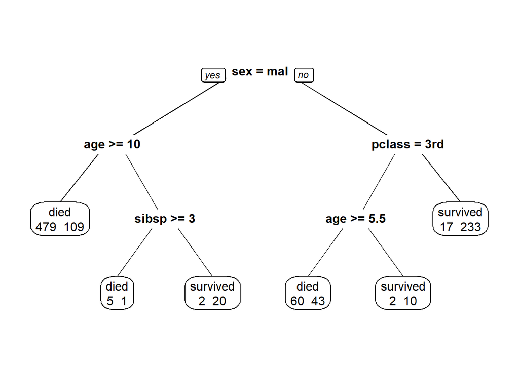

```r
ptitanic.Arbre_Opt <- prune(ptitanic.Arbre,cp=ptitanic.Arbre$cptable[which.min(ptitanic.Arbre$cptable[,4]),1])

#Affichage de l'arbre
prp(ptitanic.Arbre_Opt,extra = 1)
```

Prédictions du modèle pour le pool de données de test

```r
#prediction du modele sur les données de test
ptitanic.test_predict <- predict(ptitanic.Arbre_Opt,newdata =ptitanic.test,type = "class")
#affichons juste la prediction faite sur les 10 premiers elements
print(ptitanic.test_predict[1:10])
```

```
##  982  983  984  985  986  987  988  989  990  991
## died died died died died died died died died died
## Levels: died survived
```

```r
#Matrice de confusion
MC <- table(ptitanic.test$survived,ptitanic.test_predict)
print(MC)
```

```
##           ptitanic.test_predict
##            died survived
##   died      238        6
##   survived   77        7
```

Evaluation des performances du modèle

```r
#Erreur de classement
erreur <- 1.0-(MC[1,1]+MC[2,2]/sum(MC))
print(erreur)
```

```
## [1] -237.0213
```

```r
#Taux de prediction
prediction <- MC[2,2]/sum(MC[2,])
prediction
```

```
## [1] 0.08333333
```

Interprétation finale

```r
print(ptitanic.Arbre_Opt)
```

```
## n= 981
##
## node), split, n, loss, yval, (yprob)
##       * denotes terminal node
##
##  1) root 981 416 died (0.57594292 0.42405708)
##    2) sex=male 616 130 died (0.78896104 0.21103896)
##      4) age>=10 588 109 died (0.81462585 0.18537415) *
##      5) age< 10 28   7 survived (0.25000000 0.75000000)
##       10) sibsp>=3 6   1 died (0.83333333 0.16666667) *
##       11) sibsp< 3 22   2 survived (0.09090909 0.90909091) *
##    3) sex=female 365  79 survived (0.21643836 0.78356164)
##      6) pclass=3rd 115  53 died (0.53913043 0.46086957)
##       12) age>=5.5 103  43 died (0.58252427 0.41747573) *
##       13) age< 5.5 12   2 survived (0.16666667 0.83333333) *
##      7) pclass=1st,2nd 250  17 survived (0.06800000 0.93200000) *
```

## Conclusion :

En conclusion, ce tutotriel extrêmement bien réalisé permet de comprendre de manière simple, rapide et visuelle la création de modèles prédictifs sous formes d’arbres de décision dans un but de classification ou de regression. La construction fluide et logique du tutoriel permet de bien suivre les étapes afin de s’approprier le contenu/la méthode et d’être en mesure de l’appliquer à de futurs nouveaux cas.